# Estrutura Básica do RMarkdown

Fernanda Fiel Peres

21/07/2020

# Elementos básicos do RMarkdown

## Títulos

Os títulos são definidos pela presença e pela quantidade de #.  
Um único # define o título 1 (o maior na hierarquia), dois # definem o título 2, e assim sucessivamente.  
`# Título 1`  
`## Título 2`

## Formatação

- Para que duas frases fiquem em linhas separadas, dê dois espaços entre elas;
- Os dois espaços funcionam também para deixar uma linha em branco;
- Para deixar uma palavra em **negrito**, coloque-a entre quatro asteriscos: `**negrito**`
- Para deixar uma palavra em *itálico*, coloque-a entre dois asteriscos: `*itálico*`
- Para deixar caracteres <sup>sobrescritos</sup>, coloque-os entre acentos circunflexos: `^1^`
- Para deixar caracteres <sub>subscritos</sub>, coloque-os entre til: `~1~`
- Para destacar um termo como `código`, coloque-o entre crases (backticks): `` `código` ``
- Para criar uma citação (quote), escreva o texto após um sinal de maior: `> Citação`

> Citação

## Adicionando links, imagens e notas de rodapé

### Adicionando links:

`[Nome do Link](Endereço do Link)`

**Exemplo:**  
[Canal do YouTube](https://youtube.com/c/FernandaPeres)

### Adicionando imagens

`![Legenda](Endereço da Imagem)`

**Exemplo:**

[figure not shown]

### Criando notas de rodapé (clicáveis)

Há duas opções:

1. Escrever ao final do texto `[^1]` e então (pode ser logo abaixo, ou depois) escrever a nota de rodapé:  
   “Essa informação não é um consenso `[^1]`”  
   `[^1]: Esta é uma nota de rodapé.`
2. Colocar a informação da nota de rodapé no meio do texto, e o R numerará automaticamente:  
   “Essa informação não é um consenso `^[Esta é uma nota de rodapé]`”

**Exemplo:**

O RMarkdown é uma ferramenta excelente para documentar seus códigos e apresentar os resultados. As muitas funcionalidades dele são descritas detalhadamente no livro R Markdown: The Definitive Guide [^1].

## Criando listas

### Listas não-ordenadas:

Usamos asterisco para criar o item, sinal de adição para criar o subitem e traço para criar o sub-subitem. A cada nível devem ser dados 4 espaços antes.  
`* Item`  
`+ Subitem`  
`- Sub-subitem`

**Exemplo:**

- Item 1
  - Subitem 1
  - Subitem 2
    - Sub-subitem 1
- Item 2
- Item 3

### Listas ordenadas:

`1. Item`  
`i) Subitem`  
`A. Sub-subitem`

**Exemplo:**

1. Item 1
   1. Subitem 1
   2. Subitem 2  
      A. Sub-subitem 1
2. Item 2
3. Item 3

## Adicionando equações

As equações no RMarkdown são escritas com a linguagem LaTeX.

Para que a equação apareça no meio do texto, devemos escrevê-la entre dois cifrões: `$equação$`

“Esse cálculo é realizado pela equação $\sum_{i = 1} (x_i - \mu)^2$, como comentado no item anterior.”

Para que a equação apareça no formato destacado (display), deve ser colocada entre quatro cifrões:
`$$equação$$`

Esse cálculo é realizado através da equação abaixo:
$$\sum_{i=1}^{n}\left( \frac{X_i}{Y_i} \right)$$

# Incluindo códigos R

Para adicionar qualquer código em R, devemos iniciar com três crases, seguidas por `{r}` e para encerrar o bloco de código, devemos fechá-lo com outras três crases.

**Exemplos:**

```r
library(dplyr)
library(rstatix)
dados <- read.csv2("Banco de Dados 6.csv")
glimpse(dados)
```

```
## Rows: 48
## Columns: 4
## $ Genero   <chr> "Masculino", "Feminino", "Feminino", "Masculino", "Masculino"~
## $ Alcool   <chr> "4 Canecas", "4 Canecas", "4 Canecas", "4 Canecas", "2 Caneca~
## $ Memoria  <int> 20, 50, 55, 30, 85, 30, 30, 65, 70, 35, 80, 65, 40, 80, 75, 4~
## $ Latencia <dbl> 2.1, 5.2, 5.0, 3.8, 2.9, 3.0, 3.1, 4.2, 3.9, 2.9, 1.7, 4.0, 3~
```

Visualização do banco de dados (desformatado)

```r
head(dados, 10)
```

```
##       Genero    Alcool Memoria Latencia
## 1  Masculino 4 Canecas      20      2.1
## 2   Feminino 4 Canecas      50      5.2
## 3   Feminino 4 Canecas      55      5.0
## 4  Masculino 4 Canecas      30      3.8
## 5  Masculino 2 Canecas      85      2.9
## 6  Masculino 4 Canecas      30      3.0
## 7  Masculino 4 Canecas      30      3.1
## 8   Feminino 4 Canecas      65      4.2
## 9   Feminino 2 Canecas      70      3.9
## 10 Masculino 4 Canecas      35      2.9
```

Visualização em tabela (das 10 primeiras entradas)

```r
library(knitr)
kable(head(dados, 10))
```

| Genero | Alcool | Memoria | Latencia |
| --- | --- | --- | --- |
| Masculino | 4 Canecas | 20 | 2.1 |
| Feminino | 4 Canecas | 50 | 5.2 |
| Feminino | 4 Canecas | 55 | 5.0 |
| Masculino | 4 Canecas | 30 | 3.8 |
| Masculino | 2 Canecas | 85 | 2.9 |
| Masculino | 4 Canecas | 30 | 3.0 |
| Masculino | 4 Canecas | 30 | 3.1 |
| Feminino | 4 Canecas | 65 | 4.2 |
| Feminino | 2 Canecas | 70 | 3.9 |
| Masculino | 4 Canecas | 35 | 2.9 |

Visualização em tabela (todas as entradas, separadas em páginas)

```r
library(rmarkdown)
paged_table(dados)
```

| Genero | Alcool | Memoria | Latencia |
| --- | --- | --- | --- |
| Masculino | 4 Canecas | 20 | 2.1 |
| Feminino | 4 Canecas | 50 | 5.2 |
| Feminino | 4 Canecas | 55 | 5.0 |
| Masculino | 4 Canecas | 30 | 3.8 |
| Masculino | 2 Canecas | 85 | 2.9 |
| Masculino | 4 Canecas | 30 | 3.0 |
| Masculino | 4 Canecas | 30 | 3.1 |
| Feminino | 4 Canecas | 65 | 4.2 |
| Feminino | 2 Canecas | 70 | 3.9 |
| Masculino | 4 Canecas | 35 | 2.9 |

[output cut: 38 more lines]

**Opções para o “chunk”:**

- `eval = FALSE`: Exclui o resultado, mas não a fórmula
- `echo = FALSE`: Exclui a fórmula, mas não o resultado
- `include = FALSE`: Exclui o resultado e a fórmula, mas o chunk ainda é rodado
- `message = FALSE`: Exclui as mensagens
- `warning = FALSE`: Exclui os avisos

Usando `eval = FALSE`:

```r
boxplot(dados$Memoria ~ dados$Genero)
```

Usando `echo = FALSE`:

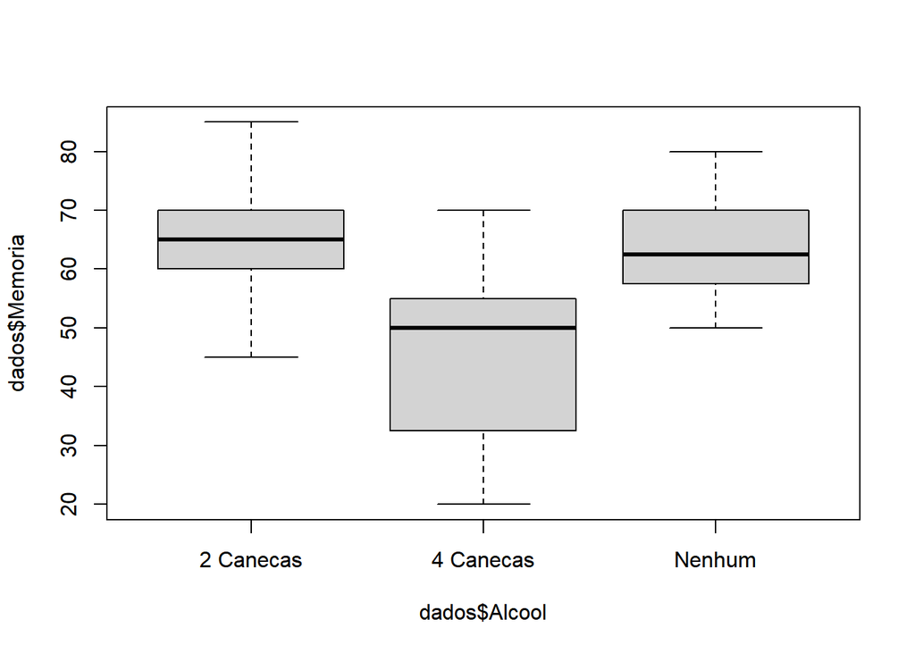

Usando `include = FALSE`:

```r
library(car)
```

```r
leveneTest(Memoria ~ Genero, dados)
```

```
## Warning in leveneTest.default(y = y, group = group, ...): group coerced to
## factor.
```

```
## Levene's Test for Homogeneity of Variance (center = median)
##       Df F value   Pr(>F)
## group  1  19.979 5.08e-05 ***
##       46
## ---
## Signif. codes:  0 '***' 0.001 '**' 0.01 '*' 0.05 '.' 0.1 ' ' 1
```

[^1]: R Markdown: The Definitive Guide. Yihui Xie, J. J. Allaire, Garrett Grolemund. Disponível em: https://bookdown.org/yihui/rmarkdown/